# Frequency Plot

Suhaas Ramani

9/17/2020

To the ad numbers on excel I made a new heading called ad_number and imported the file into R. After which I arranged and ordered the data in terms of impressions.

```r
library(tidyverse)
```

```r
library(dplyr)
library(ggplot2)
library(readxl)
library(plotly)
library(ggrepel)
library(gridExtra)
Kerala_ad <- read_excel("C:\\Users\\Suhaas Ramani\\Desktop\\R Research Project - Facebook Ads\\Filtered_Kerala_Ad_Data.xlsx")

Kerala_ad <- Kerala_ad %>%
  filter(!is.na(creation_date_notime)) %>%
  mutate(ad_number = as.numeric(ad_number)) %>%
  arrange(ad_number)

Kerala_ad$impressions <- factor(Kerala_ad$impressions, levels = c("<1K", "1K-5K", "5K-10K", "10K-50K", "50K-100K", "100K-200K", "200K-500K", "500K-1M", ">1M"))

Kerala_ad <- Kerala_ad[order(Kerala_ad$impressions),]
```

After this I realized it would be difficult to visually interpret the frequencies, impressions and ad numbers for each point with the labels if all the points were on one plot so I had to separate them into 24 plots with an approximate range of 40 observations each. Beside each point on each plot, the ad_number and the region_KL frequency are pasted and separated by a comma. Through this you will be able to visually see how many impressions each ad received, its number and the relative frequency with which it was received in the region of Kerala.

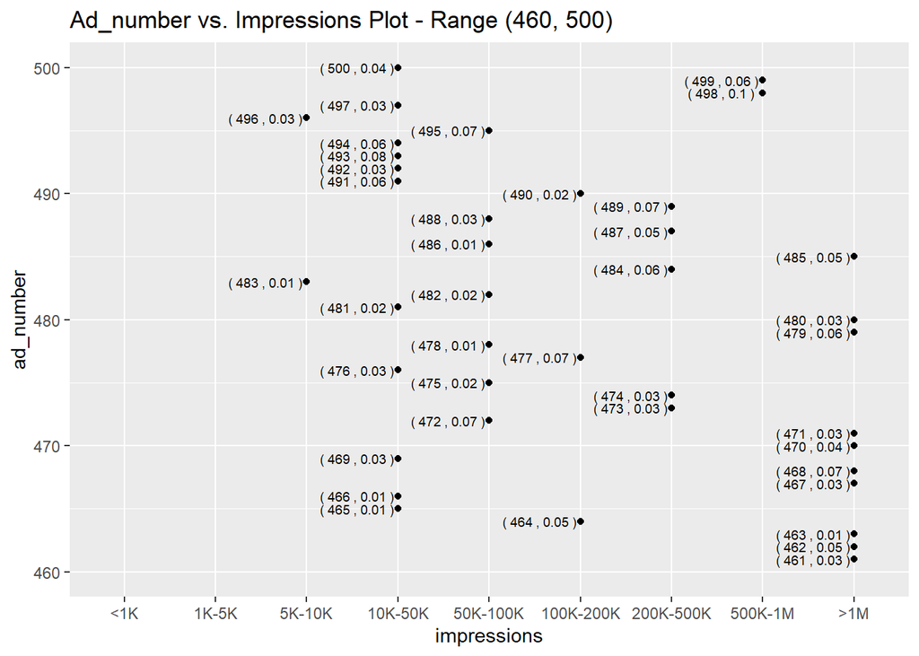

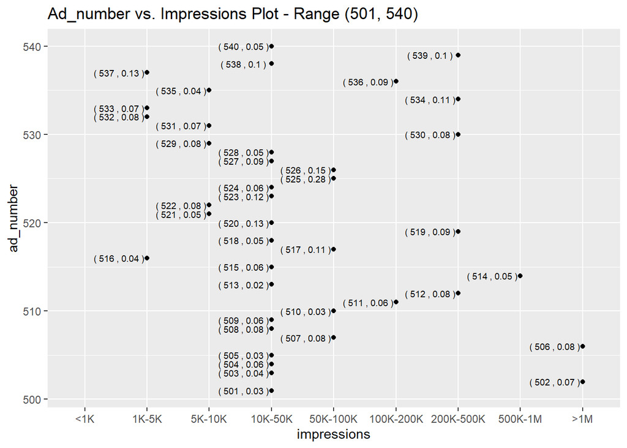

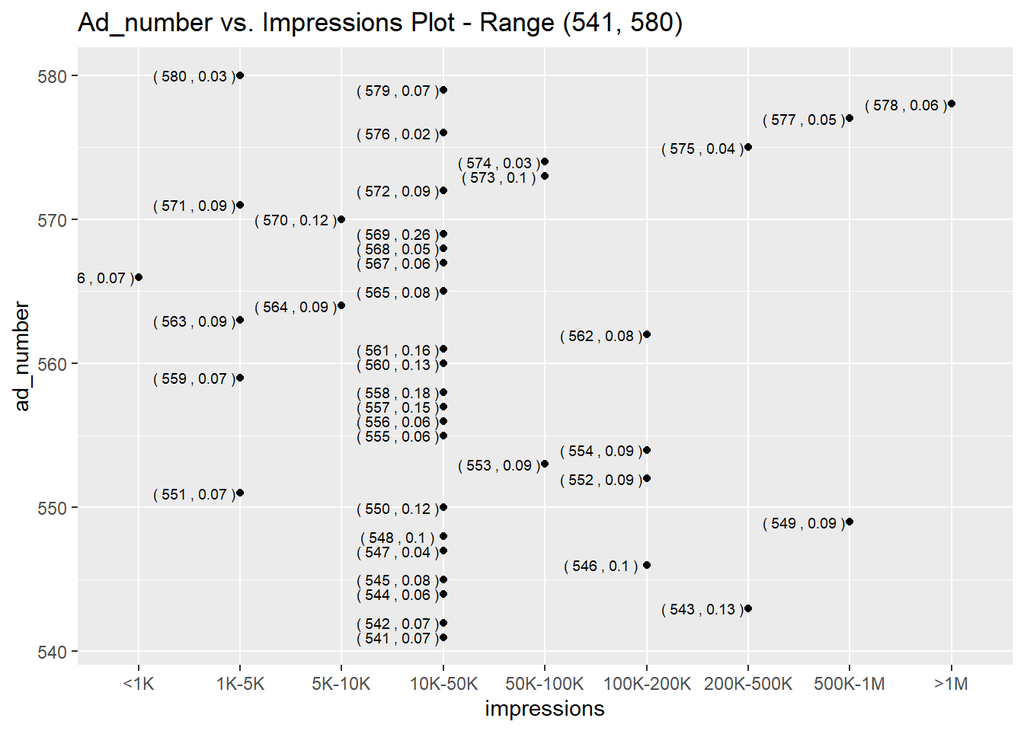

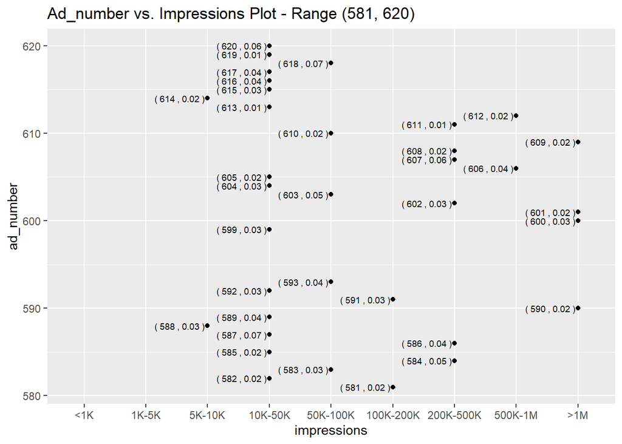

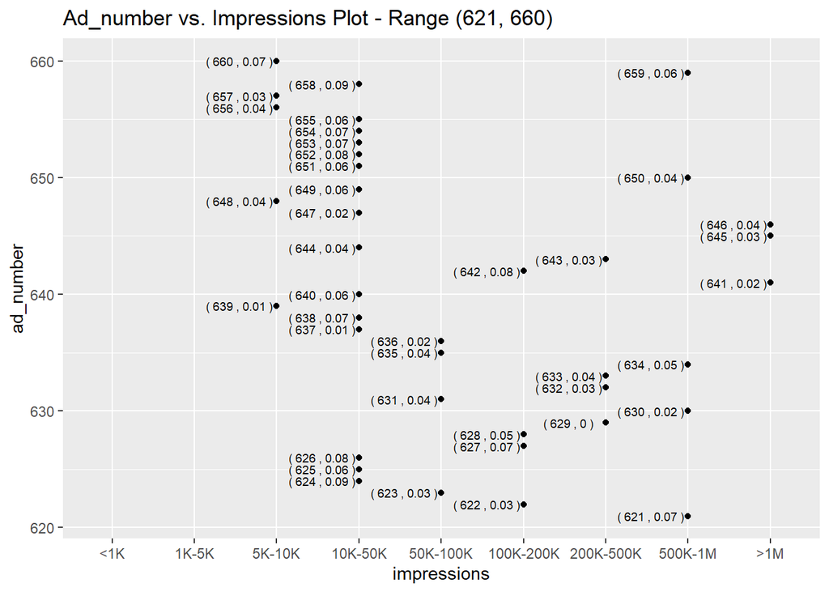

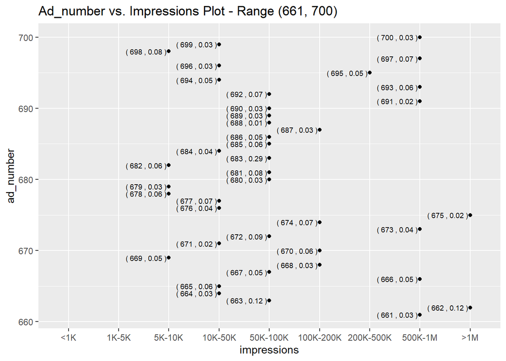

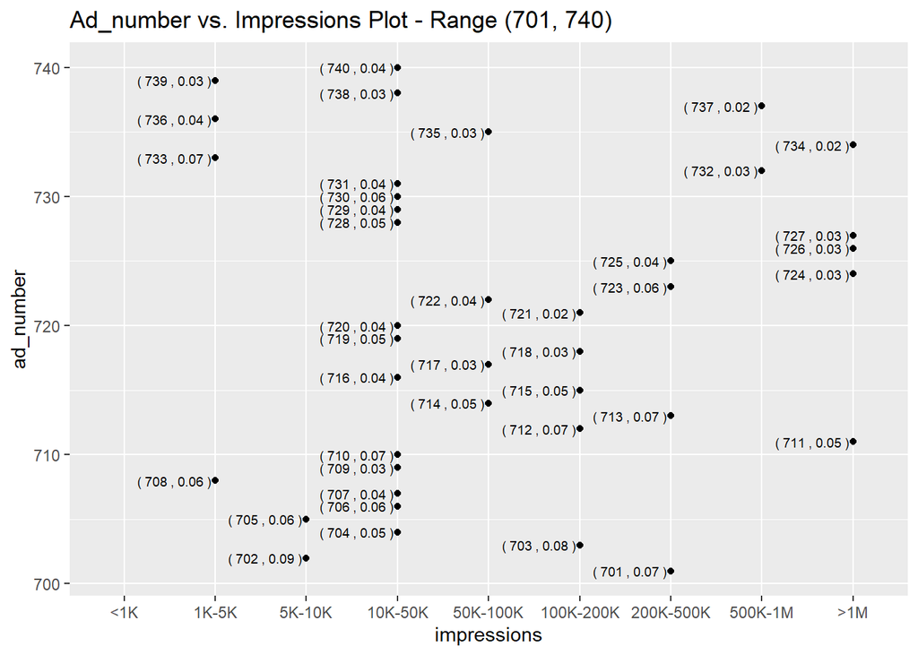

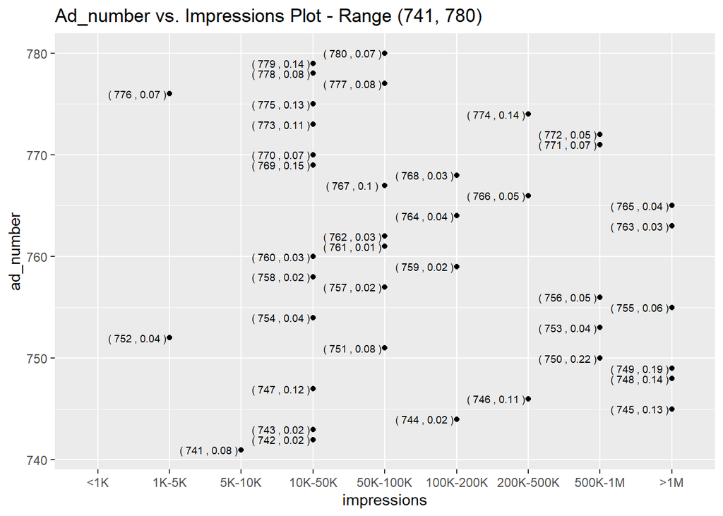

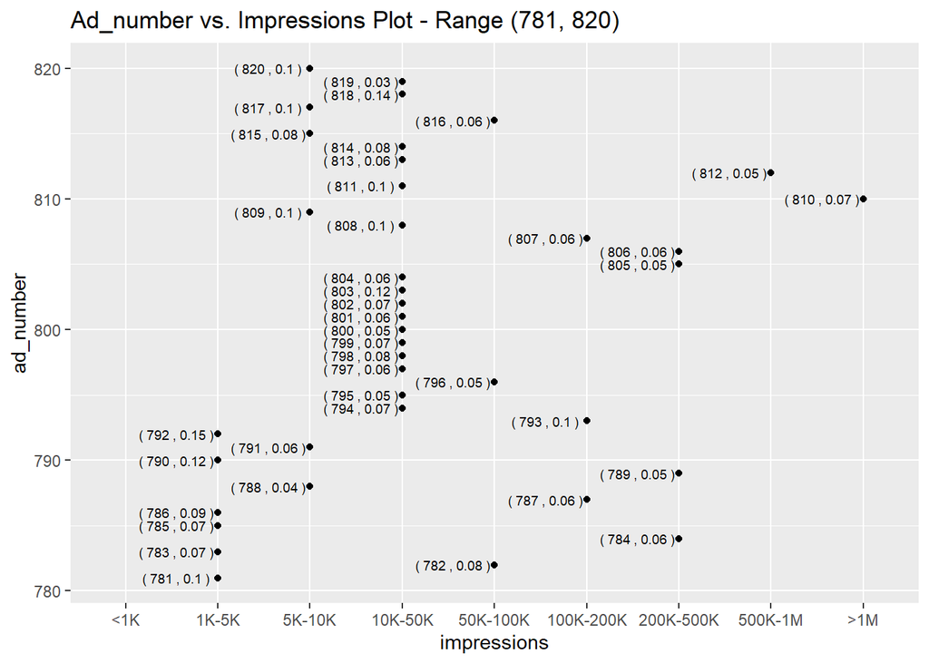

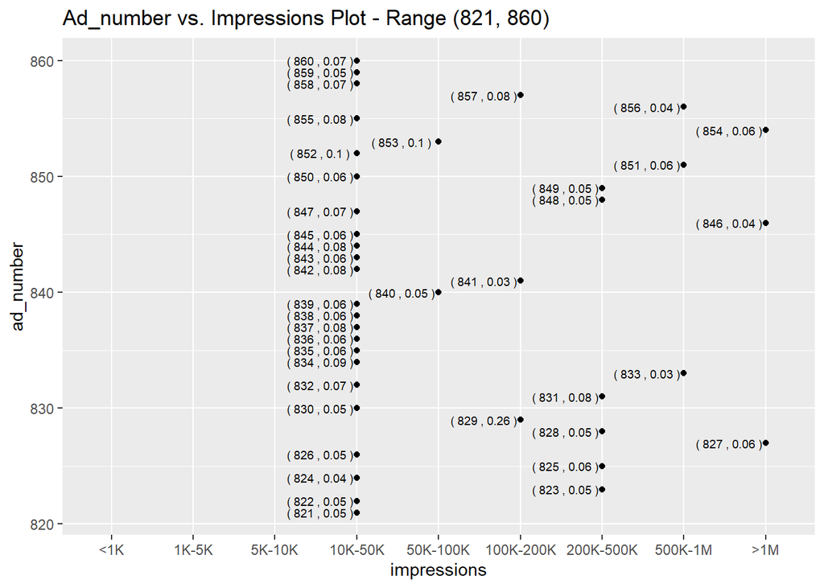

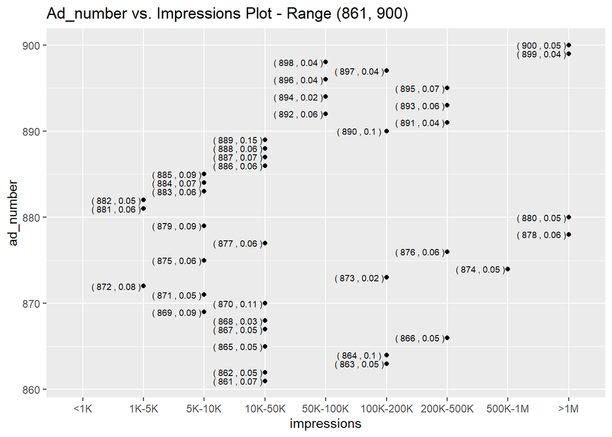

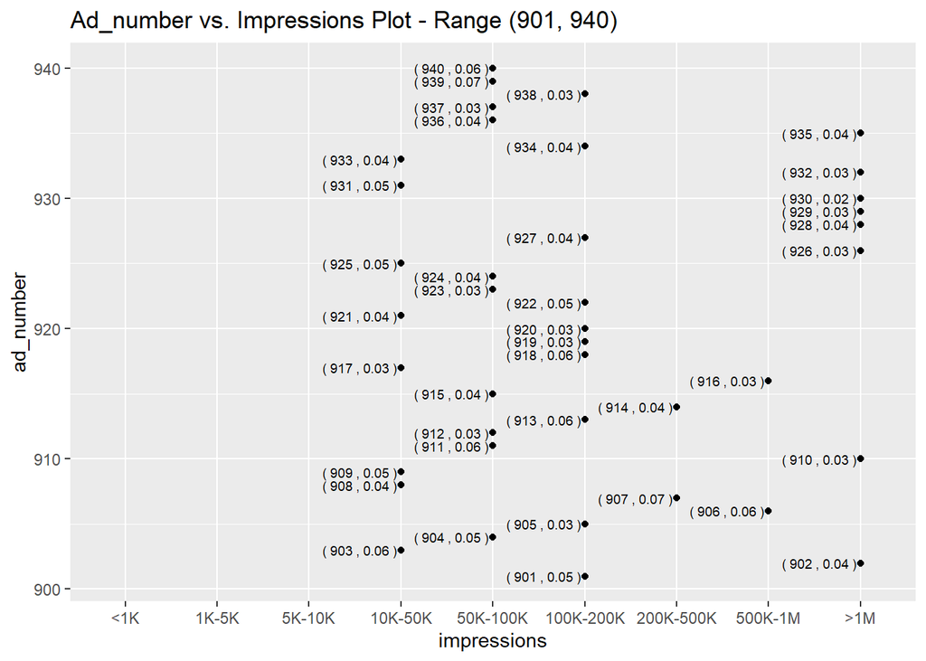

[12 more figures not shown]

I removed the final point which is ad number 2799, corresponding with 5K-10K impressions with a relative frequency of 0.17, because it was an extreme point and would not fit on a plot with the other points. I can make a separate plot with this singular point if required.